# Unit 2 Project

Ada Lazuli

Tuesday, March 24, 2026

## Front Matter

```r
remove(list = ls())
#Load libraries
library(reactable)
library(ggplot2)
library(tidyverse)
library(GGally)
library(patchwork) # used for combining plots: https://patchwork.data-imaginist.com/
library(mgcv)
library(glmnet)
library(pls)
library(leaps)
#Read datasets into Environment
cod_df <- read.csv("../../sample_data/STAT508_CODGamesP2.csv") %>% select(-Level)
seed <- 42
```

## Task 1

#### Analysis and Discussion of Method used for Calculating XP

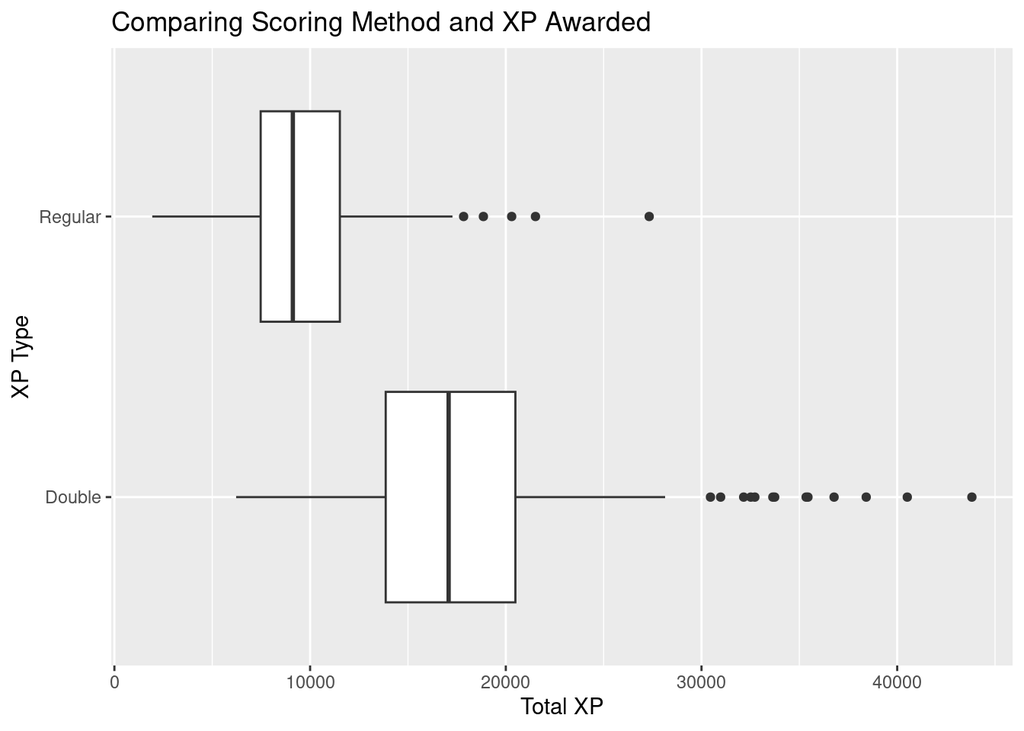

```r
summary_stats <- cod_df %>%
  group_by(XPType) %>%
  summarise(
    n = n(),
    min = min(TotalXP),
    percentile25 = quantile(TotalXP, probs = c(.25)),
    mean = round(mean(TotalXP), digits = 2),
    median = median(TotalXP),
    percentile75 = quantile(TotalXP, probs = .75),
    max = max(TotalXP),
    range = max(TotalXP) - min(TotalXP),
    standard_deviation = round(sd(TotalXP), digits = 2)
  )

ggplot(cod_df, aes(x = TotalXP, y = XPType)) +
  geom_boxplot() +
  labs(title = "Comparing Scoring Method and XP Awarded",
       y = "XP Type",
       x = "Total XP")
```

```r
reactable(summary_stats)
```

| XPType | n | min | percentile25 | mean | median | percentile75 | max | range | standard_deviation |
| --- | --- | --- | --- | --- | --- | --- | --- | --- | --- |
| Double | 330 | 6220 | 13863.25 | 17786.45 | 17078.5 | 20489.75 | 43816 | 37596 | 5705.41 |
| Regular | 205 | 1935 | 7474 | 9667.56 | 9118 | 11520 | 27327 | 25392 | 3413.21 |

The summary statistics and the boxplots show that Double has more variance and tends to award more XP than Regular. Additionally, there is a slight class imbalance with approximately 125 more observations of Double than Regular. Given that Double shows up more frequently than Regular, the model will use double as the base case and depict regular as the difference from double.

#### Analysis and Discussion of the Mode

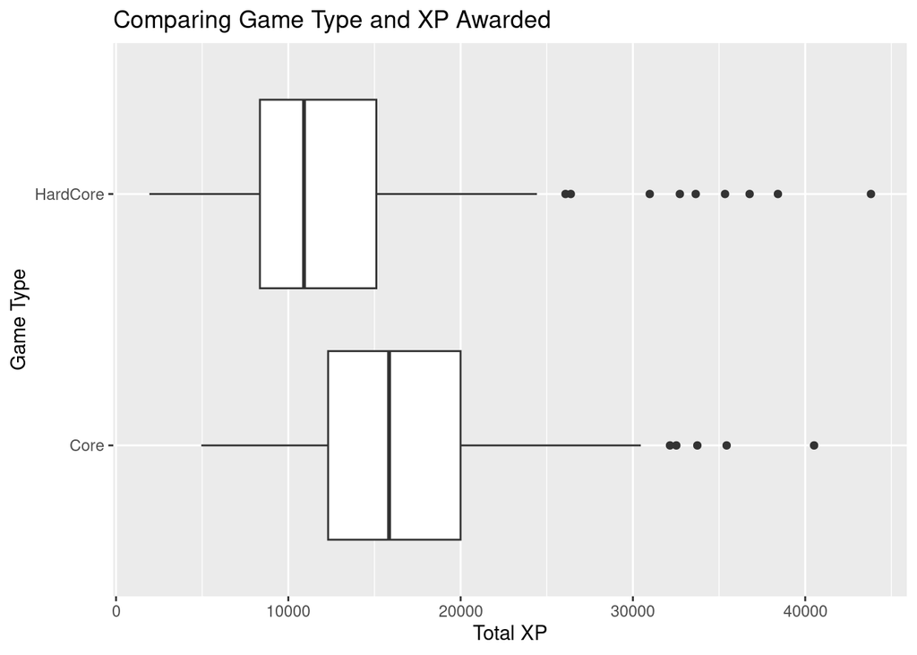

```r
summary_stats <- cod_df %>%
  group_by(Mode) %>%
  summarise(
    n = n(),
    min = min(TotalXP),
    percentile25 = quantile(TotalXP, probs = c(.25)),
    mean = round(mean(TotalXP), digits = 2),
    median = median(TotalXP),
    percentile75 = quantile(TotalXP, probs = .75),
    max = max(TotalXP),
    range = max(TotalXP) - min(TotalXP),
    standard_deviation = round(sd(TotalXP), digits = 2)
  )

ggplot(cod_df, aes(x = TotalXP, y = Mode)) +
  geom_boxplot() +
  labs(title = "Comparing Game Type and XP Awarded",
       y = "Game Type",
       x = "Total XP")
```

```r
reactable(summary_stats)
```

| Mode | n | min | percentile25 | mean | median | percentile75 | max | range | standard_deviation |
| --- | --- | --- | --- | --- | --- | --- | --- | --- | --- |
| Core | 300 | 4949 | 12309 | 16414.99 | 15847 | 19997 | 40515 | 35566 | 5692.06 |
| HardCore | 235 | 1935 | 8351 | 12454.81 | 10911 | 15108.5 | 43816 | 41881 | 6427.45 |

The summary statistics and boxplots show that Core games are more frequent and and have less variation compared to Hard Core games. However the boxplots show that the interquartile range for the modes overlap and hypothesis testing might show fail to show evidence of a difference in terms of total experience awarded. The class imbalance between Core and HardCore is less prominent with only 65 more Core observations than HardCore. Since Core has more representation, the model will use Core as the baseline and represent HardCore as a deviation from that.

## Task 2

### Part 1

Based on the preliminary analysis, XPType and Mode will be explored for use in the models. However, feature selection techniques will be utilized and Mode might be dropped.

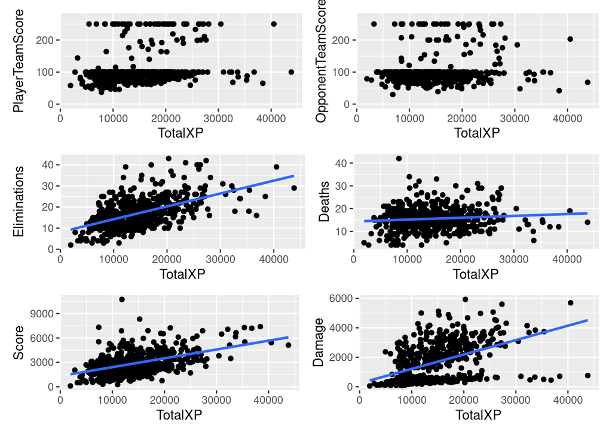

```r
sp1 <- ggplot(cod_df, aes(x = TotalXP, y = PlayerTeamScore)) + geom_point() +coord_cartesian(ylim = c(0, 270))
sp2 <- ggplot(cod_df, aes(x = TotalXP, y = OpponentTeamScore)) + geom_point() +coord_cartesian(ylim = c(0, 270))
sp3 <- ggplot(cod_df, aes(x = TotalXP, y = Eliminations)) + geom_point() + geom_smooth(method = "lm", se = FALSE)
sp4 <- ggplot(cod_df, aes(x = TotalXP, y = Deaths)) + geom_point() + geom_smooth(method = "lm", se = FALSE)
sp5 <- ggplot(cod_df, aes(x = TotalXP, y = Score)) + geom_point() + geom_smooth(method = "lm", se = FALSE)
sp6 <- ggplot(cod_df, aes(x = TotalXP, y = Damage)) + geom_point() + geom_smooth(method = "lm", se = FALSE)
(sp1 + sp2)/(sp3 + sp4)/(sp5 + sp6)
```

Based on the scatter plots, it appears that the totalXP varies by the different quantitative variables, with most showing a positive correlation. However, there is strange divergence observed in the player and opponent team score features.

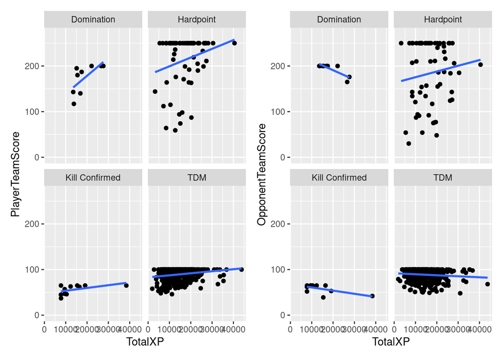

```r
sp1 <- ggplot(cod_df, aes(x = TotalXP, y = PlayerTeamScore)) + geom_point() + facet_wrap(Game ~ . )  +
  geom_smooth(method = "lm", se = FALSE) + coord_cartesian(ylim = c(0, 270))
sp2 <- ggplot(cod_df, aes(x = TotalXP, y = OpponentTeamScore)) + geom_point() + facet_wrap(Game ~ . ) +
  geom_smooth(method = "lm", se = FALSE) +coord_cartesian(ylim = c(0, 270))
sp1 + sp2
```

The divergence observed in the scatterplots for PlayerTeamScore and OpponentTeamScore is influenced by the Game due to match termination scoring thresholds.

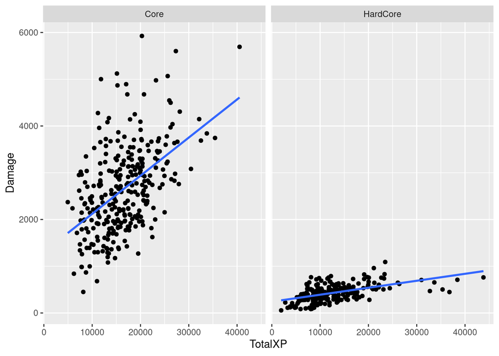

```r
ggplot(cod_df, aes(x = TotalXP, y = Damage)) + geom_point() + geom_smooth(method = "lm", se = FALSE) + facet_wrap(Mode ~ . )
```

The scatterplot shows that the relationship between totalXP and Damage is influenced by the mode. This makes sense in hindsight due to the how health is managed in the different Modes according to the data description. Lastly, the full partial feature will be included left for evalution with the feature selection and dimension reduction methods.

In short, the following variables will be used:

1. PlayerTeamScore
2. OpponentTeamScore
3. Eliminations
4. Deaths
5. Score
6. Damage
7. Mode
8. XPType
9. Game
10. FullPartial

### Part 2

```r
set.seed(seed)
trainInd <- sample(1:nrow(cod_df), floor(0.8*nrow(cod_df)), replace = FALSE)
# For linear regression
train <- cod_df[trainInd, ]
validation <- cod_df[ -trainInd,]
# For lasso with cv.glmnet
Xmat <- model.matrix(TotalXP ~ ., data = cod_df)[, -1]
yvec <- cod_df$TotalXP
XmatTrain <- Xmat[trainInd,]
XmatVal <- Xmat[-trainInd,]
yvecTrain <- yvec[trainInd]
yvecVal <- yvec[-trainInd]
```

After exploring the features available for regression, the next phase is to divide the data into train and validation sets to assess how well the developed models perform against unseen data.

To do this, a seed of 42 was used randomly to divide 80% of the data into the model training set and the remaining 20% of the validation set.

This left the training set consisting of exactly 428 observations while the validation set had the remaining 107

Next, three models will be developed using feature selection and dimension reduction techniques since limited exploration and multivariate analysis was conducted during the EDA phase.

#### Model1 Analysis and Discussion

The first model will be a linear regression. However, since it is unknown which selection of features will yield the best results, the best subsets approach will be used to decide on the best linear regression model.

```r
regfitBSval <- regsubsets(TotalXP ~ ., nvmax = 12, data = train)
summary(regfitBSval)
```

```
## Subset selection object
## Call: regsubsets.formula(TotalXP ~ ., nvmax = 12, data = train)
## 12 Variables  (and intercept)
##                    Forced in Forced out
## FullPartialPartial     FALSE      FALSE
## PlayerTeamScore        FALSE      FALSE
## OpponentTeamScore      FALSE      FALSE
## Eliminations           FALSE      FALSE
## Deaths                 FALSE      FALSE
## Score                  FALSE      FALSE
## Damage                 FALSE      FALSE
## XPTypeRegular          FALSE      FALSE
## ModeHardCore           FALSE      FALSE
## GameHardpoint          FALSE      FALSE
## GameKill Confirmed     FALSE      FALSE
## GameTDM                FALSE      FALSE
## 1 subsets of each size up to 12
## Selection Algorithm: exhaustive
##           FullPartialPartial PlayerTeamScore OpponentTeamScore Eliminations
## 1  ( 1 )  " "                " "             " "               " "
## 2  ( 1 )  " "                " "             " "               "*"
## 3  ( 1 )  " "                " "             " "               "*"
## 4  ( 1 )  " "                "*"             " "               " "
## 5  ( 1 )  "*"                "*"             " "               " "
## 6  ( 1 )  "*"                "*"             " "               " "
## 7  ( 1 )  "*"                "*"             "*"               "*"
## 8  ( 1 )  "*"                "*"             " "               "*"
## 9  ( 1 )  "*"                "*"             "*"               "*"
## 10  ( 1 ) "*"                "*"             "*"               "*"
## 11  ( 1 ) "*"                "*"             "*"               "*"
## 12  ( 1 ) "*"                "*"             "*"               "*"
##           Deaths Score Damage XPTypeRegular ModeHardCore GameHardpoint
## 1  ( 1 )  " "    " "   " "    "*"           " "          " "
## 2  ( 1 )  " "    " "   " "    "*"           " "          " "
## 3  ( 1 )  " "    "*"   " "    "*"           " "          " "
## 4  ( 1 )  " "    "*"   "*"    "*"           " "          " "
## 5  ( 1 )  " "    "*"   "*"    "*"           " "          " "
## 6  ( 1 )  " "    "*"   "*"    "*"           " "          " "
## 7  ( 1 )  " "    "*"   "*"    "*"           " "          " "
## 8  ( 1 )  " "    "*"   "*"    "*"           " "          "*"
## 9  ( 1 )  "*"    "*"   "*"    "*"           " "          " "
## 10  ( 1 ) "*"    "*"   "*"    "*"           "*"          " "
## 11  ( 1 ) "*"    "*"   "*"    "*"           "*"          "*"
## 12  ( 1 ) "*"    "*"   "*"    "*"           "*"          "*"
##           GameKill Confirmed GameTDM
## 1  ( 1 )  " "                " "
## 2  ( 1 )  " "                " "
## 3  ( 1 )  " "                " "
## 4  ( 1 )  " "                " "
## 5  ( 1 )  " "                " "
## 6  ( 1 )  "*"                " "
## 7  ( 1 )  " "                " "
## 8  ( 1 )  "*"                " "
## 9  ( 1 )  "*"                " "
## 10  ( 1 ) "*"                " "
## 11  ( 1 ) " "                "*"
## 12  ( 1 ) "*"                "*"
```

```r
validationMat <- model.matrix(TotalXP ~ ., data = validation)
trainMat <- model.matrix(TotalXP ~ ., data = train)

numModels <- ncol(validationMat) - 1
valMSE <- rep(NA, numModels)
trainMSE <- rep(NA, numModels)

for (i in 1:numModels){
  coefi <- coef(regfitBSval, id = i)
  yhat <- validationMat[, names(coefi)] %*% coefi
  valMSE[i] <- mean((validation$TotalXP - yhat)^2)
  yhat <- trainMat[, names(coefi)] %*% coefi
  trainMSE[i] <- mean((train$TotalXP - yhat)^2)
}
optSizeVal <- which.min(valMSE)
MSEdf <- data.frame(Model = 1:numModels,
                       validation = valMSE,
                       train = trainMSE) %>%
  pivot_longer(
    cols = c(validation, train),
    names_to = "Split",
    values_to =  "MSE"
  )
```

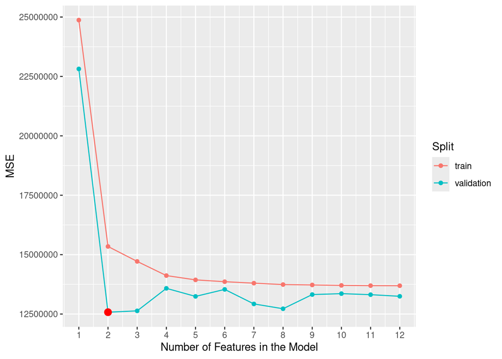

```r
ggplot(data = MSEdf, mapping = aes(x = Model, y = MSE, color = Split)) +
  geom_line() +
  geom_point() +
  scale_x_continuous(breaks = c(1: 12)) +
  labs(x = "Number of Features in the Model",
       y = "MSE") +
  geom_point(data = MSEdf[optSizeVal+1,] , color = "red", size = 3)
```

A total of 12 models were created and evaluated using the best subsets approach. Based on the validation set Mean Squared Error (MSE) scores, it appears that a linear regression with XPType and Eliminations performs the best against new data. Having all of features yields the lowest training MSE but leads to higher validation MSE compared to simpler models.

```r
model1 <- lm(TotalXP ~ Eliminations + XPType, data = train)
summary(model1)
```

```
##
## Call:
## lm(formula = TotalXP ~ Eliminations + XPType, data = train)
##
## Residuals:
##    Min     1Q Median     3Q    Max
##  -8688  -2496   -361   1765  21008
##
## Coefficients:
##               Estimate Std. Error t value Pr(>|t|)
## (Intercept)    9875.71     544.64   18.13   <2e-16 ***
## Eliminations    445.94      27.45   16.25   <2e-16 ***
## XPTypeRegular -7315.68     392.31  -18.65   <2e-16 ***
## ---
## Signif. codes:  0 '***' 0.001 '**' 0.01 '*' 0.05 '.' 0.1 ' ' 1
##
## Residual standard error: 3931 on 425 degrees of freedom
## Multiple R-squared:   0.62,  Adjusted R-squared:  0.6182
## F-statistic: 346.7 on 2 and 425 DF,  p-value: < 2.2e-16
```

```r
model1_summary <- summary(model1)
model1_Pred <- predict(model1, newdata = validation)
model1_RMSE <- sqrt(mean((validation$TotalXP - model1_Pred)^2))
model1_MAE <- mean(abs(validation$TotalXP - model1_Pred))
```

The best model built using the best subsets approach has an adjusted $r^2$of 61.82%

#### Model2 Analysis and Discussion

```r
set.seed(seed)
lassoCV <- cv.glmnet(x = XmatTrain, y = yvecTrain,
                    family = "gaussian",
                    alpha = 1,
                    lambda = NULL,
                    standardize = TRUE,
                    nfolds = 10)
```

The second model was also developed using feature selection through LASSO. The $\lambda$ tuning parameter was chosen using the best 1 standard error approach after 10 crossfold validations (CV) with the standardized training set and a randomization seed of 42.

Based on the validation scores, a $\lambda$ of 672.3 was found to be optimal. Note that all validation here was conducted with a split on the training set, not the larger validation set created previously.

```r
coefLam1se <- predict(lassoCV, s = lassoCV$lambda.1se, type = "coefficients")
tempdf <- data.frame(Variable = row.names(coefLam1se), lam1se = as.numeric(coefLam1se))
reactable(tempdf, searchable = FALSE, compact = TRUE, striped = TRUE, defaultPageSize = 13, showPageSizeOptions = FALSE)
```

| Variable | lam1se |
| --- | --- |
| (Intercept) | 10594.9404854812 |
| FullPartialPartial | 0 |
| PlayerTeamScore | 0.435420061621549 |
| OpponentTeamScore | 0 |
| Eliminations | 201.925653003516 |
| Deaths | 0 |
| Score | 0.78144868320671 |
| Damage | 0.343393253654426 |
| XPTypeRegular | -5895.38033601133 |
| ModeHardCore | 0 |

[output cut: 3 more lines]

The LASSO model pushed the coefficients of the following variables to zero, effectively removing them from the model:

1. FullPartialPartial
2. OpponentTeamScore
3. Deaths
4. Mode(Core, Hardcore)
5. Game(Hardpoint, TDM, Kill Confirmed, Domination)

```r
lassoYhat <- predict(lassoCV, s = lassoCV$lambda.1se, newx = XmatVal)
lassoRMSE <-  sqrt(mean((yvecVal - lassoYhat)^2))
lassoMAE <-  mean(abs(yvecVal - lassoYhat))
```

#### Model3 Analysis and Discussion

The third model is different in that it uses partial least squares (PLS) as a dimension reduction as opposed to the feature selection techniques used previously.

```r
set.seed(seed)
plsFit <- plsr(TotalXP  ~ PlayerTeamScore + OpponentTeamScore + Eliminations + Deaths + Score + Damage + Mode + XPType + Game, data = train,
               center = TRUE, scale = TRUE,
               validation = "CV", segments = 10) # segmentation = folds
summary(plsFit)
```

```
## Data:    X dimension: 428 11
##  Y dimension: 428 1
## Fit method: kernelpls
## Number of components considered: 11
##
## VALIDATION: RMSEP
## Cross-validated using 10 random segments.
##        (Intercept)  1 comps  2 comps  3 comps  4 comps  5 comps  6 comps
## CV            6369     4485     4035     3860     3845     3854     3861
## adjCV         6369     4483     4030     3852     3839     3847     3854
##        7 comps  8 comps  9 comps  10 comps  11 comps
## CV        3869     3871     3866      3866      3866
## adjCV     3861     3862     3858      3858      3858
##
## TRAINING: % variance explained
##          1 comps  2 comps  3 comps  4 comps  5 comps  6 comps  7 comps  8 comps
## X          29.17    52.74    63.10    74.74    79.92    87.59    92.19    97.73
## TotalXP    51.60    61.84    65.54    65.70    65.81    65.85    65.90    65.92
##          9 comps  10 comps  11 comps
## X          98.61     99.64    100.00
## TotalXP    65.93     65.93     65.93
```

The optimal number of components is 4, based on the CV score of 3845 over 10 folds with a randomization seed of 42 against the centered and scaled training set. Additionally, the model captures 74.74% of the variation in the training data and explains 65.70% of the variation in totalXP with 4 components. Note that the validation here still refers to the training set and not the separate validation set created previously. The validation set is only used for final model selection to minimize experimenter tuning bias.

```r
yhatPLS <- predict(plsFit, newdata = validation, ncomp = 4)
RMSEpls <- sqrt(mean((validation$TotalXP - yhatPLS)^2))
MAEpls <- mean(abs(validation$TotalXP - yhatPLS))
```

### Part 3

```r
performance_df <- data.frame("Model" = c("Best Subset", "LASSO", "PLS"),
                             'Validation RMSE' = c(model1_RMSE, lassoRMSE, RMSEpls),
                             'Validation MAE' = c(model1_MAE, lassoMAE, MAEpls)) %>%
                        mutate(Validation.RMSE = round(Validation.RMSE, digits = 2)) %>%
                        mutate(Validation.MAE = round(Validation.MAE, digits = 2)) %>%
                        arrange(Validation.RMSE)
reactable(performance_df)
```

| Model | Validation.RMSE | Validation.MAE |
| --- | --- | --- |
| Best Subset | 3546.51 | 2573 |
| PLS | 3557.38 | 2592.93 |
| LASSO | 3706.95 | 2774.21 |

Based on the performance against the validation set, it appears that the model created using the best subsets approach performs the best against new data as evidenced by the lower Root Mean Squared Error (RMSE) and Mean Absolute Error (MAE). This implies that the best subset model should yield the lowest error, or best performance, against new observations compared to the PLS and LASSO models.

## Task 3

Next, further regression will be done using generalized additive models (GAM). To start, a large GAM will be created to observe the effective degrees of freedom to determine whether the feature should be smoothed or left as a linear function. Additionally, subsequent models will be created in an attempt to reduce excess features.

```r
set.seed(seed)
GAMmodel1 <- gam(TotalXP  ~ s(PlayerTeamScore) + s(OpponentTeamScore) + s(Eliminations) + s(Deaths) + s(Score) + s(Damage) + Mode + XPType + Game,
                 data = cod_df)
summary(GAMmodel1)
```

```
##
## Family: gaussian
## Link function: identity
##
## Formula:
## TotalXP ~ s(PlayerTeamScore) + s(OpponentTeamScore) + s(Eliminations) +
##     s(Deaths) + s(Score) + s(Damage) + Mode + XPType + Game
##
## Parametric coefficients:
##                    Estimate Std. Error t value Pr(>|t|)
## (Intercept)         13865.4     2263.8   6.125 1.84e-09 ***
## ModeHardCore          417.7     2610.6   0.160   0.8730
## XPTypeRegular       -7163.0      347.7 -20.598  < 2e-16 ***
## GameHardpoint       -1169.4     1613.1  -0.725   0.4688
## GameKill Confirmed   4606.8     2550.5   1.806   0.0715 .
## GameTDM              4018.3     2055.5   1.955   0.0511 .
## ---
## Signif. codes:  0 '***' 0.001 '**' 0.01 '*' 0.05 '.' 0.1 ' ' 1
##
## Approximate significance of smooth terms:
##                        edf Ref.df      F  p-value
## s(PlayerTeamScore)   1.000  1.000 13.778 0.000229 ***
## s(OpponentTeamScore) 3.530  4.396  2.002 0.083281 .
## s(Eliminations)      8.125  8.728  3.314 0.002793 **
## s(Deaths)            2.325  3.017  2.115 0.097539 .
## s(Score)             5.626  6.811  9.192  < 2e-16 ***
## s(Damage)            7.295  8.304  2.054 0.051116 .
## ---
## Signif. codes:  0 '***' 0.001 '**' 0.01 '*' 0.05 '.' 0.1 ' ' 1
##
## R-sq.(adj) =  0.693   Deviance explained = 71.2%
## GCV = 1.3152e+07  Scale est. = 1.2319e+07  n = 535
```

Based on the model summary, it appears that the mode feature should be removed due to the t test statistic. This is reasonable due to the overlapping IQR between Core and HardCore observed previously.

```r
set.seed(seed)
GAMmodel2 <- gam(TotalXP  ~ s(PlayerTeamScore) + s(OpponentTeamScore) + s(Eliminations) + s(Deaths) + s(Score) + s(Damage)  + XPType + Game,
                 data = cod_df)
summary(GAMmodel2)
```

```
##
## Family: gaussian
## Link function: identity
##
## Formula:
## TotalXP ~ s(PlayerTeamScore) + s(OpponentTeamScore) + s(Eliminations) +
##     s(Deaths) + s(Score) + s(Damage) + XPType + Game
##
## Parametric coefficients:
##                    Estimate Std. Error t value Pr(>|t|)
## (Intercept)         14057.3     1905.7   7.376 6.77e-13 ***
## XPTypeRegular       -7160.1      347.1 -20.627  < 2e-16 ***
## GameHardpoint       -1209.9     1603.7  -0.754   0.4510
## GameKill Confirmed   4602.6     2546.1   1.808   0.0713 .
## GameTDM              4012.6     2052.5   1.955   0.0511 .
## ---
## Signif. codes:  0 '***' 0.001 '**' 0.01 '*' 0.05 '.' 0.1 ' ' 1
##
## Approximate significance of smooth terms:
##                        edf Ref.df      F  p-value
## s(PlayerTeamScore)   1.000  1.000 13.857 0.000220 ***
## s(OpponentTeamScore) 3.531  4.398  2.027 0.079818 .
## s(Eliminations)      8.129  8.731  3.917 0.000411 ***
## s(Deaths)            2.329  3.021  2.193 0.088063 .
## s(Score)             5.631  6.817  9.493  < 2e-16 ***
## s(Damage)            7.413  8.366  3.373 0.000923 ***
## ---
## Signif. codes:  0 '***' 0.001 '**' 0.01 '*' 0.05 '.' 0.1 ' ' 1
##
## R-sq.(adj) =  0.694   Deviance explained = 71.2%
## GCV = 1.3103e+07  Scale est. = 1.2294e+07  n = 535
```

Next, appears that the Game feature should be removed based on the t test statistic. This is also reasonable due to the significant class imbalances in the observed game modes, as seen here:

```r
table(cod_df$Game)
```

```
##
##     Domination      Hardpoint Kill Confirmed            TDM
##              9             61             11            454
```

```r
set.seed(seed)
GAMmodel3 <- gam(TotalXP  ~ s(PlayerTeamScore) + s(OpponentTeamScore) + s(Eliminations) + s(Deaths) + s(Score) + s(Damage)  + XPType,
                 data = cod_df)
summary(GAMmodel3)
```

```
##
## Family: gaussian
## Link function: identity
##
## Formula:
## TotalXP ~ s(PlayerTeamScore) + s(OpponentTeamScore) + s(Eliminations) +
##     s(Deaths) + s(Score) + s(Damage) + XPType
##
## Parametric coefficients:
##               Estimate Std. Error t value Pr(>|t|)
## (Intercept)    17437.7      202.8   85.97   <2e-16 ***
## XPTypeRegular  -7208.7      348.6  -20.68   <2e-16 ***
## ---
## Signif. codes:  0 '***' 0.001 '**' 0.01 '*' 0.05 '.' 0.1 ' ' 1
##
## Approximate significance of smooth terms:
##                        edf Ref.df     F  p-value
## s(PlayerTeamScore)   1.526  1.841 3.351 0.025009 *
## s(OpponentTeamScore) 3.170  3.895 1.664 0.182113
## s(Eliminations)      8.451  8.875 3.995 0.000244 ***
## s(Deaths)            1.943  2.514 1.988 0.121199
## s(Score)             5.682  6.867 9.578  < 2e-16 ***
## s(Damage)            6.680  7.795 3.168 0.001966 **
## ---
## Signif. codes:  0 '***' 0.001 '**' 0.01 '*' 0.05 '.' 0.1 ' ' 1
##
## R-sq.(adj) =  0.689   Deviance explained = 70.6%
## GCV = 1.3193e+07  Scale est. = 1.2467e+07  n = 535
```

Based on the t test statistic, the smoothed opponentteamscore feature should be removed.

```r
set.seed(seed)
GAMmodel4 <- gam(TotalXP  ~ s(PlayerTeamScore) + s(Eliminations) + s(Deaths) + s(Score) + s(Damage)  + XPType,
                 data = cod_df)
summary(GAMmodel4)
```

```
##
## Family: gaussian
## Link function: identity
##
## Formula:
## TotalXP ~ s(PlayerTeamScore) + s(Eliminations) + s(Deaths) +
##     s(Score) + s(Damage) + XPType
##
## Parametric coefficients:
##               Estimate Std. Error t value Pr(>|t|)
## (Intercept)    17444.9      203.8   85.62   <2e-16 ***
## XPTypeRegular  -7227.5      350.0  -20.65   <2e-16 ***
## ---
## Signif. codes:  0 '***' 0.001 '**' 0.01 '*' 0.05 '.' 0.1 ' ' 1
##
## Approximate significance of smooth terms:
##                      edf Ref.df     F  p-value
## s(PlayerTeamScore) 1.340  1.592 6.626 0.002388 **
## s(Eliminations)    8.510  8.898 4.139 0.000118 ***
## s(Deaths)          1.539  1.934 0.998 0.304950
## s(Score)           5.702  6.890 9.402  < 2e-16 ***
## s(Damage)          6.854  7.951 3.170 0.001746 **
## ---
## Signif. codes:  0 '***' 0.001 '**' 0.01 '*' 0.05 '.' 0.1 ' ' 1
##
## R-sq.(adj) =  0.686   Deviance explained = 70.1%
## GCV = 1.3233e+07  Scale est. = 1.2591e+07  n = 535
```

Next, it appears that the smoothed deaths should be removed based on the t test statistic

```r
set.seed(seed)
GAMmodel5 <- gam(TotalXP  ~ s(PlayerTeamScore) + s(Eliminations) + s(Score) + s(Damage)  + XPType,
                 data = cod_df)
summary(GAMmodel5)
```

```
##
## Family: gaussian
## Link function: identity
##
## Formula:
## TotalXP ~ s(PlayerTeamScore) + s(Eliminations) + s(Score) + s(Damage) +
##     XPType
##
## Parametric coefficients:
##               Estimate Std. Error t value Pr(>|t|)
## (Intercept)      17456        204   85.58   <2e-16 ***
## XPTypeRegular    -7258        350  -20.74   <2e-16 ***
## ---
## Signif. codes:  0 '***' 0.001 '**' 0.01 '*' 0.05 '.' 0.1 ' ' 1
##
## Approximate significance of smooth terms:
##                      edf Ref.df      F  p-value
## s(PlayerTeamScore) 1.000  1.000 13.301 0.000293 ***
## s(Eliminations)    8.470  8.884  4.320 6.38e-05 ***
## s(Score)           5.736  6.924  9.126  < 2e-16 ***
## s(Damage)          6.665  7.790  3.117 0.002300 **
## ---
## Signif. codes:  0 '***' 0.001 '**' 0.01 '*' 0.05 '.' 0.1 ' ' 1
##
## R-sq.(adj) =  0.685   Deviance explained = 69.8%
## GCV = 1.323e+07  Scale est. = 1.264e+07  n = 535
```

Next, due to the perfect 1 effective degree of freedom, it appears that the PlayerTeamScore should be left as a linear function and not wrapping in a smoothing function.2

```r
set.seed(seed)
GAMmodel6 <- gam(TotalXP  ~ PlayerTeamScore  + s(Eliminations) + s(Score) + s(Damage) + XPType,
                 data = cod_df)
summary(GAMmodel6)
```

```
##
## Family: gaussian
## Link function: identity
##
## Formula:
## TotalXP ~ PlayerTeamScore + s(Eliminations) + s(Score) + s(Damage) +
##     XPType
##
## Parametric coefficients:
##                  Estimate Std. Error t value Pr(>|t|)
## (Intercept)     15959.063    454.608  35.105  < 2e-16 ***
## PlayerTeamScore    14.376      3.942   3.647 0.000292 ***
## XPTypeRegular   -7257.489    349.982 -20.737  < 2e-16 ***
## ---
## Signif. codes:  0 '***' 0.001 '**' 0.01 '*' 0.05 '.' 0.1 ' ' 1
##
## Approximate significance of smooth terms:
##                   edf Ref.df     F  p-value
## s(Eliminations) 8.470  8.884 4.320 6.38e-05 ***
## s(Score)        5.736  6.924 9.126  < 2e-16 ***
## s(Damage)       6.665  7.790 3.117   0.0023 **
## ---
## Signif. codes:  0 '***' 0.001 '**' 0.01 '*' 0.05 '.' 0.1 ' ' 1
##
## R-sq.(adj) =  0.685   Deviance explained = 69.8%
## GCV = 1.323e+07  Scale est. = 1.264e+07  n = 535
```

Lastly, since the linear model created under task 2 is a simplified version of a GAM, it would interesting to observe how a GAM with smoothed eliminations and XPType performs.

```r
set.seed(seed)
GAMmodel7 <- gam(TotalXP  ~ s(Eliminations) +  XPType,
                 data = cod_df)
summary(GAMmodel7)
```

```
##
## Family: gaussian
## Link function: identity
##
## Formula:
## TotalXP ~ s(Eliminations) + XPType
##
## Parametric coefficients:
##               Estimate Std. Error t value Pr(>|t|)
## (Intercept)    17521.9      211.9   82.70   <2e-16 ***
## XPTypeRegular  -7428.4      346.8  -21.42   <2e-16 ***
## ---
## Signif. codes:  0 '***' 0.001 '**' 0.01 '*' 0.05 '.' 0.1 ' ' 1
##
## Approximate significance of smooth terms:
##                   edf Ref.df     F p-value
## s(Eliminations) 7.843  8.602 43.14  <2e-16 ***
## ---
## Signif. codes:  0 '***' 0.001 '**' 0.01 '*' 0.05 '.' 0.1 ' ' 1
##
## R-sq.(adj) =  0.637   Deviance explained = 64.3%
## GCV = 1.484e+07  Scale est. = 1.4567e+07  n = 535
```

#### GAM Selection and Analysis

Now, the 7 GAM models created previously will be trained on the training data set then evaluated against the validation data set to assess performance against new observations.

```r
set.seed(seed)
GAMmodel1 <- gam(TotalXP  ~ s(PlayerTeamScore) + s(OpponentTeamScore) + s(Eliminations) + s(Deaths) + s(Score) + s(Damage) + Mode + XPType + Game,
                 data = train)
GAMmodel1_summary <- summary(GAMmodel1)

set.seed(seed)
GAMmodel2 <- gam(TotalXP  ~ s(PlayerTeamScore) + s(OpponentTeamScore) + s(Eliminations) + s(Deaths) + s(Score) + s(Damage)  + XPType + Game,
                 data = train)
GAMmodel2_summary <- summary(GAMmodel2)

set.seed(seed)
GAMmodel3 <- gam(TotalXP  ~ s(PlayerTeamScore) + s(OpponentTeamScore) + s(Eliminations) + s(Deaths) + s(Score) + s(Damage)  + XPType,
                 data = train)
GAMmodel3_summary <- summary(GAMmodel3)

set.seed(seed)
GAMmodel4 <- gam(TotalXP  ~ s(PlayerTeamScore) + s(Eliminations) + s(Deaths) + s(Score) + s(Damage)  + XPType,
                 data = train)
GAMmodel4_summary <- summary(GAMmodel4)

set.seed(seed)
GAMmodel5 <- gam(TotalXP  ~ s(PlayerTeamScore) + s(Eliminations) + s(Score) + s(Damage)  + XPType,
                 data = train)
GAMmodel5_summary <- summary(GAMmodel5)

set.seed(seed)
GAMmodel6 <- gam(TotalXP  ~ PlayerTeamScore  + s(Eliminations) + s(Score) + s(Damage) + XPType,
                 data = train)
GAMmodel6_summary <- summary(GAMmodel6)

set.seed(seed)
GAMmodel7 <- gam(TotalXP  ~ s(Eliminations) +  XPType,
                 data = train)
GAMmodel7_summary <- summary(GAMmodel7)


GAMmodel1_Pred <- predict(GAMmodel1, newdata = validation)
GAMmodel1_RMSE <- sqrt(mean((validation$TotalXP - GAMmodel1_Pred)^2))
GAMmodel1_MAE <- mean(abs(validation$TotalXP - GAMmodel1_Pred))


GAMmodel2_Pred <- predict(GAMmodel2, newdata = validation)
GAMmodel2_RMSE <- sqrt(mean((validation$TotalXP - GAMmodel2_Pred)^2))
GAMmodel2_MAE <- mean(abs(validation$TotalXP - GAMmodel2_Pred))

GAMmodel3_Pred <- predict(GAMmodel3, newdata = validation)
GAMmodel3_RMSE <- sqrt(mean((validation$TotalXP - GAMmodel3_Pred)^2))
GAMmodel3_MAE <- mean(abs(validation$TotalXP - GAMmodel3_Pred))

GAMmodel4_Pred <- predict(GAMmodel4, newdata = validation)
GAMmodel4_RMSE <- sqrt(mean((validation$TotalXP - GAMmodel4_Pred)^2))
GAMmodel4_MAE <- mean(abs(validation$TotalXP - GAMmodel4_Pred))

GAMmodel5_Pred <- predict(GAMmodel5, newdata = validation)
GAMmodel5_RMSE <- sqrt(mean((validation$TotalXP - GAMmodel5_Pred)^2))
GAMmodel5_MAE <- mean(abs(validation$TotalXP - GAMmodel5_Pred))

GAMmodel6_Pred <- predict(GAMmodel6, newdata = validation)
GAMmodel6_RMSE <- sqrt(mean((validation$TotalXP - GAMmodel6_Pred)^2))
GAMmodel6_MAE <- mean(abs(validation$TotalXP - GAMmodel6_Pred))

GAMmodel7_Pred <- predict(GAMmodel7, newdata = validation)
GAMmodel7_RMSE <- sqrt(mean((validation$TotalXP - GAMmodel7_Pred)^2))
GAMmodel7_MAE <- mean(abs(validation$TotalXP - GAMmodel7_Pred))

gam_results <- data.frame(Model = c('GAM 1', 'GAM 2', 'GAM 3', 'GAM 4', 'GAM 5', 'GAM 6', 'GAM 7'),
                        'Validation RMSE' = c(GAMmodel1_RMSE, GAMmodel2_RMSE, GAMmodel3_RMSE, GAMmodel4_RMSE, GAMmodel5_RMSE, GAMmodel6_RMSE, GAMmodel7_RMSE),
                        'Validation MAE' = c(GAMmodel1_MAE, GAMmodel2_MAE, GAMmodel3_MAE, GAMmodel4_MAE, GAMmodel5_MAE, GAMmodel6_MAE, GAMmodel7_MAE),
                        "R.Sq" = c(GAMmodel1_summary$r.sq, GAMmodel2_summary$r.sq, GAMmodel3_summary$r.sq, GAMmodel4_summary$r.sq, GAMmodel5_summary$r.sq, GAMmodel6_summary$r.sq, GAMmodel7_summary$r.sq),
                        BIC = c(BIC(GAMmodel1), BIC(GAMmodel2),BIC(GAMmodel3),BIC(GAMmodel4),BIC(GAMmodel5),BIC(GAMmodel6),BIC(GAMmodel7))) %>%

                        mutate(Validation.RMSE = round(Validation.RMSE, digits = 2)) %>%
                        mutate(Validation.MAE = round(Validation.MAE, digits = 2)) %>%
                        mutate(R.Sq = round(R.Sq*100, digits = 2)) %>%
                        mutate(BIC = round(BIC, digits = 2)) %>%
                        arrange(Validation.RMSE)

reactable(gam_results)
```

| Model | Validation.RMSE | Validation.MAE | R.Sq | BIC |
| --- | --- | --- | --- | --- |
| GAM 4 | 3388.95 | 2574.83 | 67.44 | 8356.63 |
| GAM 6 | 3389.89 | 2564.97 | 67.38 | 8349.62 |
| GAM 5 | 3392.36 | 2566.24 | 67.44 | 8350 |
| GAM 2 | 3432.48 | 2613.5 | 68.04 | 8379.3 |
| GAM 1 | 3451.04 | 2642.98 | 67.97 | 8381.85 |
| GAM 3 | 3484.96 | 2622.63 | 68.08 | 8362.37 |
| GAM 7 | 3546.51 | 2573 | 61.82 | 8320.64 |

Based on performance against the validation set, it seems that GAM4 and GAM6 are the best. Both are able to explain approximately 67% of the variation in TotalXP, have similiar Bayesian Information Criterion (BIC) scores, RMSE scores, and MAE scores. However, despite the slightly higher RMSE, GAM6 has a slightly better MAE and BIC, along with being less complicated.

As a result, GAM6 appears to be the best choice of all 7 GAMs created.

#### Analysis, Discussion, and Comparison of Results

The apparent best model from task 2 was the model developed through the best subsets approach. Moreover, the best model from Task 3 was GAM 6.

```r
performance_df <- data.frame("Model" = c("Best Subset", "GAM"),
                             'Validation RMSE' = c(model1_RMSE, GAMmodel6_RMSE),
                             'Validation MAE' = c(model1_MAE, GAMmodel6_MAE),
                             "R.Sq" = c(model1_summary$adj.r.squared, GAMmodel6_summary$r.sq),
                             BIC = c(BIC(model1), BIC(GAMmodel6)))%>%
                        mutate(Validation.RMSE = round(Validation.RMSE, digits = 2)) %>%
                        mutate(Validation.MAE = round(Validation.MAE, digits = 2)) %>%
                        mutate(R.Sq = round(R.Sq*100, digits = 2)) %>%
                        mutate(BIC = round(BIC, digits = 2)) %>%
                        arrange(Validation.RMSE)
reactable(performance_df)
```

| Model | Validation.RMSE | Validation.MAE | R.Sq | BIC |
| --- | --- | --- | --- | --- |
| GAM | 3389.89 | 2564.97 | 67.38 | 8349.62 |
| Best Subset | 3546.51 | 2573 | 61.82 | 8320.64 |

Of the two remaining models, the GAM performs the best against new data, as determined through the RMSE and MAE scores against the validation set. Additionally, the GAM can explain 5.56 % more of the variation in TotalXP.

The only saving grace for the best subsets model is that it is significantly simpler and has a slightly better BIC score.

In summary, for optimal predictive performance, the GAM is the best model model.

However, if a player needs a quick napkin math estimate of the XP that will be awarded, the following equations derived from the best subset model will provide a rough estimate:

$$\begin{aligned}
&\textbf{For a Double XP Match:} \\
&\quad Total\ XP = 445.95 \times (Num\ Eliminations) + 9875.71 \\
\\
&\textbf{For a Regular XP Match:} \\
&\quad Total \ XP = 445.95 \times (Num\ Eliminations) + 2560.03 \\
\end{aligned}$$